# 数字图像处理实验作业五 频域滤波器变换

赵子瑞 自动化钱61 2160405068 2019年3月23日

### 摘要

本文通过频域滤波器变换的基本方法，实现了图像的低通和高通的高斯滤波处理，图像的低通和高通的巴特沃斯滤波处理，实现了频域的非锐化掩蔽，laplace高通滤波器处理。本次试验加深了我利用频域变化和滤波器完成相应的图像增强的理解，让我对频域处理图像的知识有了更深刻的理解。

## 项目任务

本次实验的任务分为以下几点：

- 1频域低通滤波器：设计低通滤波器包括 butterworth and Gaussian (选择合适的半径，计算功率谱比),平滑测试图像test1和2;分析各自优缺点；
- 2频域高通滤波器：设计高通滤波器包括butterworth and Gaussian，在频域增强边缘。选择半径和计算功率谱比，测试图像test3,4：分析各自优缺点；
- 3其他高通滤波器：拉普拉斯和Unmask，对测试图像test3,4滤波；分析各自优缺点；

## 滤波实现原理

本次试验是通过频域滤波器对图像进行处理，处理过程可以用以下公式描述。 对图像进行傅里叶变换 $$F(x,y) = \xi\{ f(x,y)\}$$ 图像在频域通过滤波器 $$G(u,v) = F(u,v)H(u,v)$$ 在进行傅里叶反变换，得到滤波后图像。 $$g(x,y) = \xi^{-1}\{ G(u,v)\}$$

### Butterworth filtering

Butterworth filtering 低通滤波器的公式如下所示。

$$H(u,v) = \frac{1}{1+\left[D(u,v)/D_0\right]^{2n}}$$

将其可视化为如下结果。

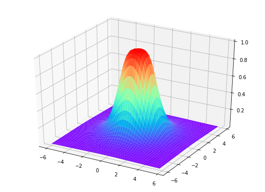

```python
from matplotlib import pyplot as plt
import numpy as np
from mpl_toolkits.mplot3d import Axes3D

fig = plt.figure(figsize = (7,5))
ax = Axes3D(fig)
X = np.arange(-6, 6, 0.25)
Y = np.arange(-6, 6, 0.25)
X, Y = np.meshgrid(X, Y)
R = np.sqrt(X**2 + Y**2)
Z = 1/(1+(R/2)**4)
ax.plot_surface(X, Y, Z, rstride=1, cstride=1, cmap='rainbow')
plt.show()
```

Butterworth filtering 高通滤波器的公式如下所示。

$$H(u,v) = \frac{1}{1+\left[D_0/D(u,v)\right]^{2n}}$$

将其可视化为如下结果。

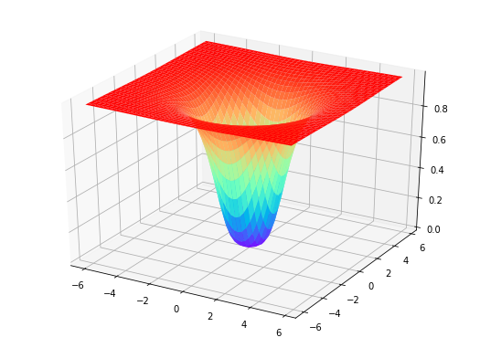

```python
fig = plt.figure(figsize = (7,5))
ax = Axes3D(fig)
X = np.arange(-6, 6, 0.25)
Y = np.arange(-6, 6, 0.25)
X, Y = np.meshgrid(X, Y)
R = np.sqrt(X**2 + Y**2)
Z = 1/(1+(2/R)**4)
ax.plot_surface(X, Y, Z, rstride=1, cstride=1, cmap='rainbow')
plt.show()
```

### Gaussian filtering

Gaussian filtering 低通滤波器可以由下面的公式给出

$$H(u,v) = e^{-D^2(u,v)/2\sigma^2}$$

可视化结果如下所示

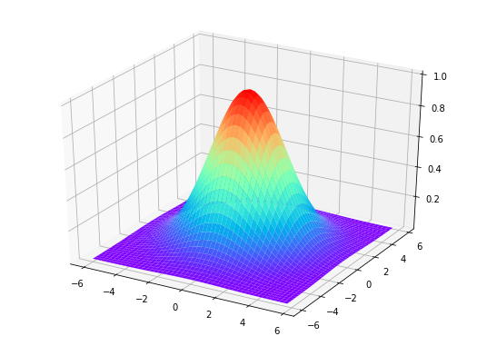

```python
fig = plt.figure(figsize = (7,5))
ax = Axes3D(fig)
s = 2
Z = np.exp(-R**2/(2*s**2))
ax.plot_surface(X, Y, Z, rstride=1, cstride=1, cmap='rainbow')
plt.show()
```

Gaussian filtering 高通滤波器可以由下面的公式给出

$$H(u,v) = 1-e^{-D^2(u,v)/2\sigma^2}$$

可视化结果如下所示

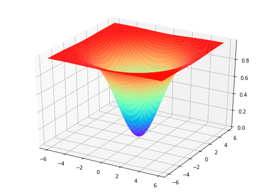

```python
fig = plt.figure(figsize = (7,5))
ax = Axes3D(fig)
s = 2
Z = 1-np.exp(-R**2/(2*s**2))
ax.plot_surface(X, Y, Z, rstride=1, cstride=1, cmap='rainbow')
plt.show()
```

### Laplacian

频率域的拉普拉斯算子实现可以用如下公式表述。

$$H(u,v)=-4\pi^2(u^2+v^2)$$

可视化结果如下所示。

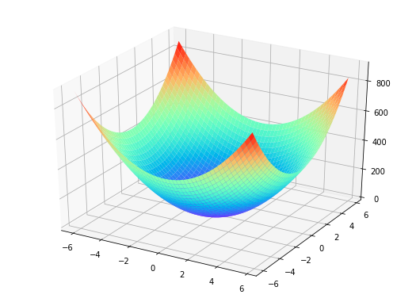

```python
from math import pi
fig = plt.figure(figsize = (7,5))
ax = Axes3D(fig)
Z = 4*pi*R**2
ax.plot_surface(X, Y, Z, rstride=1, cstride=1, cmap='rainbow')
plt.show()
```

### Unsharp Masking

钝化模板可以用如下公式表述

$$g_{mask}(x,y)=f(x,y)-f_{LP}(x,y)$$$$f_{LP}(x,y)=\Im^{-1}\left[H_{LP}(u,v)F(u,v)\right]$$$$g(x,y)=f(x,y)+k*g_{mask}(x,y)$$

## 频域低通滤波器变换

### 实验结果

巴特沃斯低通滤波器处理结果如下

[figure not shown]

从图像中可以看出，图片通过巴特沃斯低通滤波器后，图像明显变得模糊，截止阈值越小，通过的能量越小，图像越模糊。

高斯滤波器的处理结果如下

[figure not shown]

从图像结果中可以看出，模糊效果和巴特沃斯滤波器类似。

功率谱比如下

| image | butterworth 25 | butterworth 50 | butterworth 75 | gaussian 25 | gaussian 50 | gaussian 75 |
| --- | --- | --- | --- | --- | --- | --- |
| test1 | 0.9742 | 0.9909 | 0.9957 | 0.9679 | 0.9867 | 0.9927 |
| test2 | 0.9804 | 0.9884 | 0.9915 | 0.9777 | 0.9868 | 0.9904 |

## 频域高通滤波器测试

### 实验结果

巴特沃斯滤波器处理结果如下

[figure not shown]

可以看出，图像的边缘被有效的提取了,提取的边缘的强度与滤波阈值有关。

图像增强结果如下

[figure not shown]

图像增强结果如下

[figure not shown]

高斯高通滤波器处理结果如下

[figure not shown]

图像增强结果如下

[figure not shown]

图像增强结果如下

[figure not shown]

功率谱比为

| image | butterworth 25 | butterworth 50 | butterworth 75 | gaussian 25 | gaussian 50 | gaussian 75 |
| --- | --- | --- | --- | --- | --- | --- |
| test1 | 0.0022 | 0.0002 | 0.00004 | 0.0019 | 0.0002 | 0.00006 |
| test2 | 0.0070 | 0.0018 | 0.0007 | 0.0056 | 0.0015 | 0.0006 |

## Laplacian & Unsharp Masking频域滤波测试

### 实验结果

[figure not shown]

增强效果

[figure not shown]

增强效果

[figure not shown]

## 小结

本次作业图像较多，通过opencv fft算法的辅助实现的频域滤波函数的同时，也实现了Laplace算子滤波和Unsharp Masking滤波的基本函数，加深了我对理论知识的理解，也增强了我的代码动手能力。